# Has there been a polarization of working hours? Analysis of the European Union Labor Force Survey

# Problematic and motivations

Both academic and public debates suggest that there has been a polarization of working hours. Some people are working very short hours—the underemployed, and some work very long hours—the overworked. Further, longer hours are concentrated among those with higher earnings and shorter hours among those with low earnings. Such a polarization has important consequences, not just for social inequality overall, but also for the lives of the individual workers.

But is this actually true? This Stat’App will investigate this question by analyzing long-running survey data to assess trends in working hours across European countries. We will make use of unconditional quantile regression and Oaxaca-Blinder decompositions. These models enable us to understand, which group, like single-mothers or physicians, contribute to changes in the working hour distribution over time.

```r
source(file = "~/work/Stat_app/DATA/exporting_data_from_link.R")
```

[output not shown]

```r
source(file="~/work/Stat_app/Countries/countries_code.R")
```

[output not shown]

```r
#Packages :

install.packages("dplyr")
```

[output not shown]

```r
install.packages("ggplot2")
```

[output not shown]

```r
install.packages("labelled")
install.packages("haven")
```

[output not shown]

```r
install.packages("openxlsx")
```

[output not shown]

```r
install.packages("reshape2")
install.packages("openxlsx")
install.packages("haven")
install.packages("ggplot2")
```

[output not shown]

```r
install.packages("dplyr")
```

[output not shown]

```r
library("openxlsx")
library("dplyr")
library("ggplot2")
library("labelled")
library("haven")
library("magrittr")
```

# Descriptive statistics

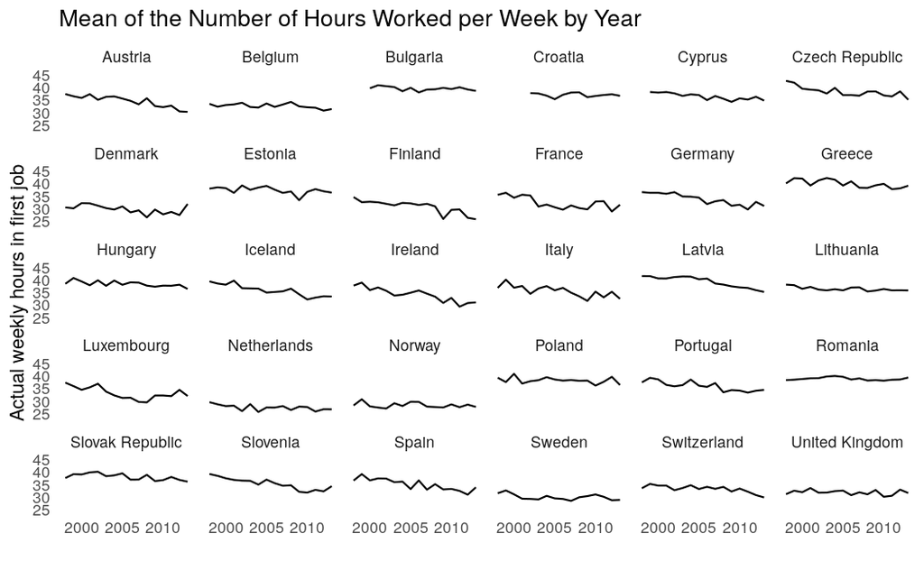

```r
# Convert the "year" and "country" variable to a factor for correct visualization in the histogram
eulfs_small$year <- as.factor(eulfs_small$year)
eulfs_small$country <- as.factor(eulfs_small$country)

# Remove values 99 (not applicable) from the hwactual variable
eulfs_small$hwactual <- na_if(eulfs_small$hwactual, 99)
# Filter data to exclude NA values in the hwactual variable
eulfs_filtered <- eulfs_small %>% filter(!is.na(hwactual))
eulfs_filtered <- merge(eulfs_filtered, countries_code, by="country")

mean_by_country_year <- eulfs_filtered %>%
  group_by(country_name, year) %>%
  summarise(mean_hwactual = mean(hwactual, na.rm = TRUE))
mean_by_country_year<- mean_by_country_year %>%
  filter(country_name != "Malta")
mean_by_country_year$year <- as.numeric(as.character(mean_by_country_year$year))

ggplot(mean_by_country_year, aes_string(x = "year", y = "mean_hwactual",group=1)) +
  geom_line() +
  labs(
    title = "Mean of the Number of Hours Worked per Week by Year",
    x = "",
    y = "Actual weekly hours in first job"
  ) +
  theme_minimal()+
  ylim(25,45)+
  facet_wrap(~country_name)+
  scale_x_continuous(breaks = c(2000,2005,2010))+
  theme(panel.grid = element_blank())
install.packages("dplyr")
install.packages("ggplot2")
```

###An histogram of the mean of the number of hours actually worked in main job per week, by country

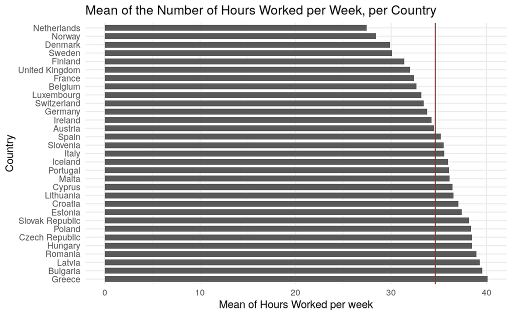

```r
##An histogram of the mean of the number of hours actually worked in main job by country

# Convert the "country" variable to a factor for correct visualization in the bar plot
eulfs_small$country <- as.factor(eulfs_small$country)

# Remove values 99 (not applicable) from the hwactual variable
eulfs_small$hwactual <- na_if(eulfs_small$hwactual, 99)

# Filter data to exclude NA values in the hwactual variable
eulfs_filtered_country <- eulfs_small %>% filter(!is.na(hwactual))

# Calculate the mean of the number of hours worked for each country
mean_by_country <- eulfs_filtered_country %>%
  group_by(country) %>%
  summarise(mean_hwactual = mean(hwactual, na.rm = TRUE))
# Merge mean_by_country with countries_code
mean_by_country <- merge(mean_by_country, countries_code, by = "country")


mean_value_EU <- mean(eulfs_filtered_country$hwactual)

# Create a horizontal bar plot
ggplot(mean_by_country, aes(x = mean_hwactual, y = reorder(country_name, -mean_hwactual))) +

  # Add horizontal bars to the plot
  geom_col(width = 0.7) +
  # Add labels and title to the plot
  labs(
    title = "Mean of the Number of Hours Worked per Week, per Country",
    x = "Mean of Hours Worked per week",
    y = "Country"
  ) +
  geom_vline(xintercept = mean_value_EU, linetype = "solid", color = "red") +
  # Set the theme to minimal
  theme_minimal()
```

```r
### First step: the number of hours people usually work
# Get the density estimate
dens1 <- density(eulfs_small$hwusual, na.rm = TRUE)
# Need to delete negative values for the number of working hours, as well as the values above 80 hours which are absent to the dataset
# Need for x and y with the same length
n <- length(dens1[[1]])
dens1[[1]] <- dens1[[1]][!(dens1[[1]] < 0)]
n_1 <- length(dens1[[1]])
loss_1 <- n - n_1 # number of first elements that were deleted
dens1[[1]] <- dens1[[1]][!(dens1[[1]] > 80)]
loss_2 <- n_1 - length(dens1[[1]]) # number of last elements that were deleted
dens1[[2]] <- tail(dens1[[2]],-loss_1)
dens1[[2]] <- head(dens1[[2]], -loss_2)

### Second step: the number of hours people wish
# Very similar case
# Get the density estimate
dens2 <- density(eulfs_small$hwwish, na.rm = TRUE)
# Need to delete negative values for the number of working hours, as well as the values above 80 hours which are absent to the dataset
# Need for x and y with the same length
n <- length(dens2[[1]])
dens2[[1]] <- dens2[[1]][!(dens2[[1]] > 80)]
loss <- n - length(dens2[[1]]) # number of last elements that were deleted
dens2[[2]] <- head(dens2[[2]], -loss)

### Plot
# Plot y-values scaled by number of observations against x values
par(mar = c(5.1, 5.1, 4.1, 2.1))
plot <- plot(dens2$x, dens2$y,type="l",xlab="Number of hours",ylab="", main = "Distribution of the number of hours", las = 2)
lines(dens1$x, dens1$y, col = "red")
```

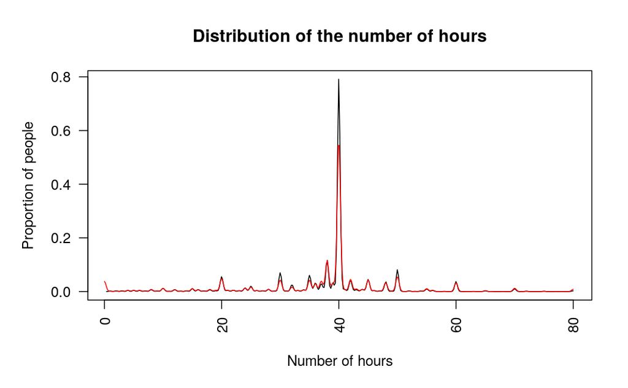

```r
title(ylab = "Proportion of people", line = 3) # a readable y-label
```

Figure 3. **The vast majority of Europeans work between 35 and 40 hours a week but those who work the 20 and 60 hours represent both strong minorities**. Density of the number of hours usually worked (in red) and density of the number of hours people wish to work (in black), all years combined. 31 countries from the 2014 release of the EU Labor Force Survey, own analyses.

The peak of the distribution is clearly between 35 and 40 hours with more than half of the population. However, it may be useful to zoom in to focus on the peak.

```r
### First step: the number of hours people usually work
# Get the density estimate
dens1 <- density(eulfs_small$hwusual, na.rm = TRUE)
# Need to delete some values for the number of working hours, to have a clearer graph
# Need for x and y with the same length
n <- length(dens1[[1]])
dens1[[1]] <- dens1[[1]][!(dens1[[1]] < 30)]
n_1 <- length(dens1[[1]])
loss_1 <- n - n_1 # number of first elements that were deleted
dens1[[1]] <- dens1[[1]][!(dens1[[1]] > 50)]
loss_2 <- n_1 - length(dens1[[1]]) # number of last elements that were deleted
dens1[[2]] <- tail(dens1[[2]],-loss_1)
dens1[[2]] <- head(dens1[[2]], -loss_2)
# Plot y-values scaled by number of observations against x values

### Second step: the number of hours people wish
# Very similar case
# Get the density estimate
dens2 <- density(eulfs_small$hwwish, na.rm = TRUE)
# Need to delete negative values for the number of working hours, as well as the values above 80 hours which are absent to the dataset
# Need for x and y with the same length
n <- length(dens2[[1]])
dens2[[1]] <- dens2[[1]][!(dens2[[1]] < 30)]
n_1 <- length(dens2[[1]])
loss_a <- n - n_1
dens2[[1]] <- dens2[[1]][!(dens2[[1]] > 50)]
loss_b <- n_1 - length(dens2[[1]]) # number of last elements that were deleted
dens2[[2]] <- tail(dens2[[2]], -loss_a)
dens2[[2]] <- head(dens2[[2]], -loss_b)


### Plot
# Plot y-values scaled by number of observations against x values
par(mar = c(5.1, 5.1, 4.1, 2.1))
plot <- plot(dens2$x, dens2$y,type="l",xlab="Number of hours",ylab="", main = "Distribution of the number of hours", las = 2)
lines(dens1$x, dens1$y, col = "red")
```

```r
text(c(2,2),c(37,35),labels=c("Non-case","Case"))
text(x = 2, y = 3, "This is my text")
```

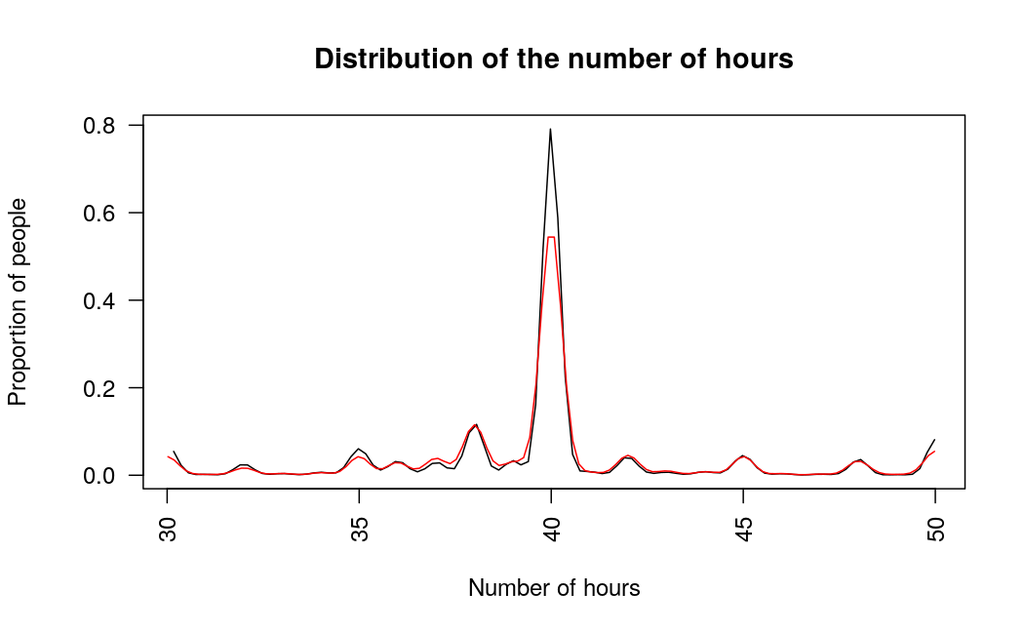

```r
title(ylab = "Proportion of people", line = 4) # a readable y-label
```

Figure 4. **A majority of workers wish to conform to the norm**. Density of the number of hours usually worked (in red) and density of the number of hours people wish to work (in black), all years combined. 31 countries from the 2014 release of the EU Labor Force Survey, own analyses.

The vast majority of Europeans seem to work between 40 hours a week but those who wish to work 40 hours are also a majority. Who are the people who want to work 40 hours?

```r
### First step: the number of hours people usually work globally
# Get the density estimate
dens1 <- density(eulfs_small$hwusual, na.rm = TRUE)
# Need to delete some values for the number of working hours, to have a clearer graph
# Need for x and y with the same length
n <- length(dens1[[1]])
dens1[[1]] <- dens1[[1]][!(dens1[[1]] < 0)]
n_1 <- length(dens1[[1]])
loss_1 <- n - n_1 # number of first elements that were deleted
dens1[[1]] <- dens1[[1]][!(dens1[[1]] > 80)]
loss_2 <- n_1 - length(dens1[[1]]) # number of last elements that were deleted
dens1[[2]] <- tail(dens1[[2]],-loss_1)
dens1[[2]] <- head(dens1[[2]], -loss_2)

# Let's focus on the people who wish to work 40 hours
eulfs_40wish <- eulfs_small %>% filter(hwwish == 40)

### Second step: the number of hours people usually work when they wish to work 40 hours
# Get the density estimate
dens3 <- density(eulfs_40wish$hwusual, na.rm = TRUE)
# Need to delete negative values for the number of working hours, as well as the values above 80 hours which are absent to the dataset
# Need for x and y with the same length
n <- length(dens3[[1]])
dens3[[1]] <- dens3[[1]][!(dens3[[1]] < 0)]
n_1 <- length(dens3[[1]])
loss_1 <- n - n_1 # number of first elements that were deleted
dens3[[1]] <- dens3[[1]][!(dens3[[1]] > 80)]
loss_2 <- n_1 - length(dens3[[1]]) # number of last elements that were deleted
dens3[[2]] <- tail(dens3[[2]],-loss_1)
dens3[[2]] <- head(dens3[[2]], -loss_2)

# Let's focus on the people who wish to work 40 hours but who don't work 40
eulfs_no40 <- eulfs_small %>% filter(hwwish == 40, hwusual != 40)

### Second step: the number of hours people usually work when they wish to work 40 hours
# Get the density estimate
dens2 <- density(eulfs_no40$hwusual, na.rm = TRUE)
# Need to delete negative values for the number of working hours, as well as the values above 80 hours which are absent to the dataset
# Need for x and y with the same length
n <- length(dens2[[1]])
dens2[[1]] <- dens2[[1]][!(dens2[[1]] < 0)]
n_1 <- length(dens2[[1]])
loss_1 <- n - n_1 # number of first elements that were deleted
dens2[[1]] <- dens2[[1]][!(dens2[[1]] > 80)]
loss_2 <- n_1 - length(dens2[[1]]) # number of last elements that were deleted
dens2[[2]] <- tail(dens2[[2]],-loss_1)
dens2[[2]] <- head(dens2[[2]], -loss_2)

### Plot
# Plot y-values scaled by number of observations against x values
par(mar = c(5.1, 5.1, 4.1, 2.1))
plot <- plot(dens1$x, dens1$y,type="l",xlab="Number of hours",ylab="", main = "Distribution of the number of hours", las = 2)
lines(dens3$x, dens3$y, col = "blue")
```

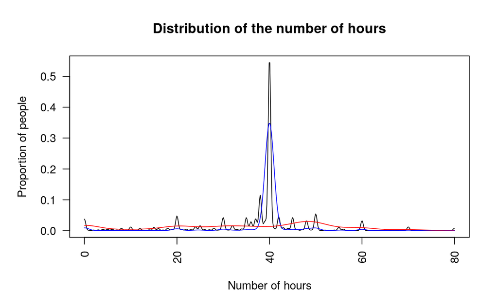

```r
lines(dens2$x, dens2$y, col = "red")
title(ylab = "Proportion of people", line = 3) # a readable y-label
```

Figure 5. **People find their number of working hours somewhat satisfactory**. Density of the number of hours usually worked: in black for all workers combined, in blue for people who wish to work 40 hours in their main job and in red for people who wish to work 40 hours but usually do not. All years combined. 31 countries from the 2014 release of the EU Labor Force Survey, own analyses.

But how many hours do people far from the norm wish to work?

```r
### First step: the number of hours people wish to work globally -------
# Get the density estimate
dens1 <- density(eulfs_small$hwwish, na.rm = TRUE)
# Need to delete values under 0 and over 80
# Need for x and y with the same length
n <- length(dens1[[1]])
dens1[[1]] <- dens1[[1]][!(dens1[[1]] < 0)] # elements < 0 deleted
n_1 <- length(dens1[[1]]) # length of the new list
loss_1 <- n - n_1 # number of first elements that were deleted
dens1[[1]] <- dens1[[1]][!(dens1[[1]] > 80)]
loss_2 <- n_1 - length(dens1[[1]]) # number of last elements that were deleted
if (loss_1!=0){
dens1[[2]] <- tail(dens1[[2]],-loss_1)
}
if (loss_2!=0){
dens1[[2]] <- head(dens1[[2]], -loss_2)
}

### Second step: focus on the people who work less than 30 hours -------
eulfs_30usual <- eulfs_small %>% filter(hwusual <= 30)

# Get the density estimate
dens2 <- density(eulfs_30usual$hwwish, na.rm = TRUE)
# Need to delete values under 0 and over 80
# Need for x and y with the same length
n <- length(dens2[[1]])
dens2[[1]] <- dens2[[1]][!(dens2[[1]] < 0)] # elements < 0 deleted
n_1 <- length(dens2[[1]]) # length of the new list
loss_1 <- n - n_1 # number of first elements that were deleted
dens2[[1]] <- dens2[[1]][!(dens2[[1]] > 80)]
loss_2 <- n_1 - length(dens2[[1]]) # number of last elements that were deleted
if (loss_1!=0){
dens2[[2]] <- tail(dens2[[2]],-loss_1)
}
if (loss_2!=0){
dens2[[2]] <- head(dens2[[2]], -loss_2)
}

### Third step: focus on the people who work more than 50 hours -------
eulfs_50usual <- eulfs_small %>% filter(hwusual >= 50)

# Get the density estimate
dens3 <- density(eulfs_50usual$hwwish, na.rm = TRUE)
# Need to delete values under 0 and over 80
# Need for x and y with the same length
n <- length(dens3[[1]])
dens3[[1]] <- dens3[[1]][!(dens3[[1]] < 0)] # elements < 0 deleted
n_1 <- length(dens3[[1]]) # length of the new list
loss_1 <- n - n_1 # number of first elements that were deleted
dens3[[1]] <- dens3[[1]][!(dens3[[1]] > 80)]
loss_2 <- n_1 - length(dens3[[1]]) # number of last elements that were deleted
if (loss_1!=0){
dens3[[2]] <- tail(dens3[[2]],-loss_1)
}
if (loss_2!=0){
dens3[[2]] <- head(dens3[[2]], -loss_2)
}
```

```r
##### Plot -------
# Plot y-values scaled by number of observations against x values
par(mar = c(5.1, 5.1, 4.1, 2.1))
plot <- plot(dens1$x, dens1$y,type="l",xlab="Number of hours",ylab="", main = "Distribution of the number of hours wished by workers", las = 2)
lines(dens2$x, dens2$y, col = "red")
```

```r
lines(dens3$x, dens3$y, col = "blue")
title(ylab = "Proportion of people", line = 3) # a readable y-label
```

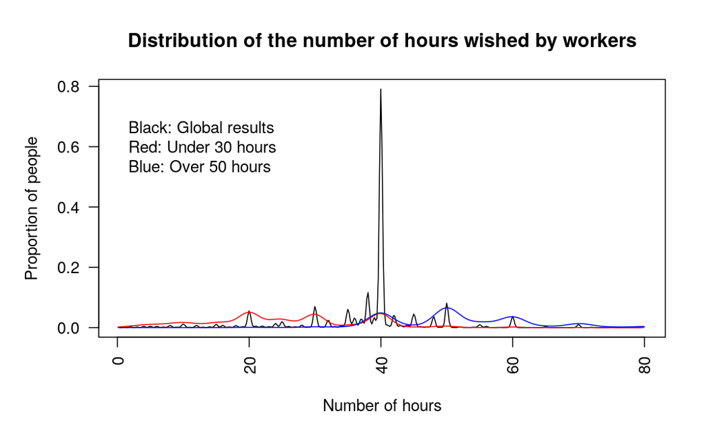

```r
text(0.6, " Black: Global results \n Red: Under 30 hours \n Blue: Over 50 hours", adj = 0)
```

```r
# Aesthetics could be better...
```

Figure 6. **People whose working hours are significantly far from the mean have different preferences compared with average workers**. Density of the number of hours wish to work: in black for all workers combined, in red for people who usually work less than 30 hours in their main job and in blue for people who work more than 50 hours in their main job, all years combined. 31 countries from the 2014 release of the EU Labor Force Survey, own analyses.

We may conclude by saying that workers face constraints that lead them to choose more (respectively less) hours than the average, apart from the number of hours they are offered. For instance, looking on children or on the elderly may partly explain the fact that people who work less than 30 hours in main job almost never want to work more than 40.

Comparaison between men and women

-Comparison between men and women concerning the number of hours actually worked in main job

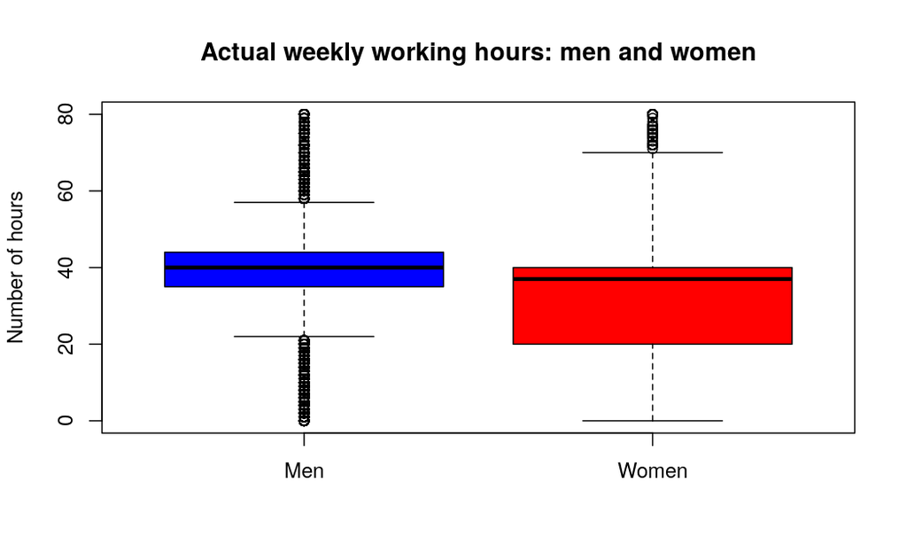

```r
# Boxplot to compare men and women concerning the number of hours actually worked in main job
boxplot(eulfs_small$hwactual ~ eulfs_small$sex,
        xlab = " ",
        ylab = "Number of hours",
        names = c("Men", "Women"),
        col = c("blue", "red"),
        main = "Actual weekly working hours: men and women"
)
```

Figure 6. **Although the median number of working hours is almost the same for each sex, the variability is much higher for women**. Boxplot of the number of hours actually worked depending on sex, all years combined. 31 countries from the 2014 release of the EU Labor Force Survey, own analyses.

The variability is much higher for female workers: their first quartile that is close from the minimum of men.

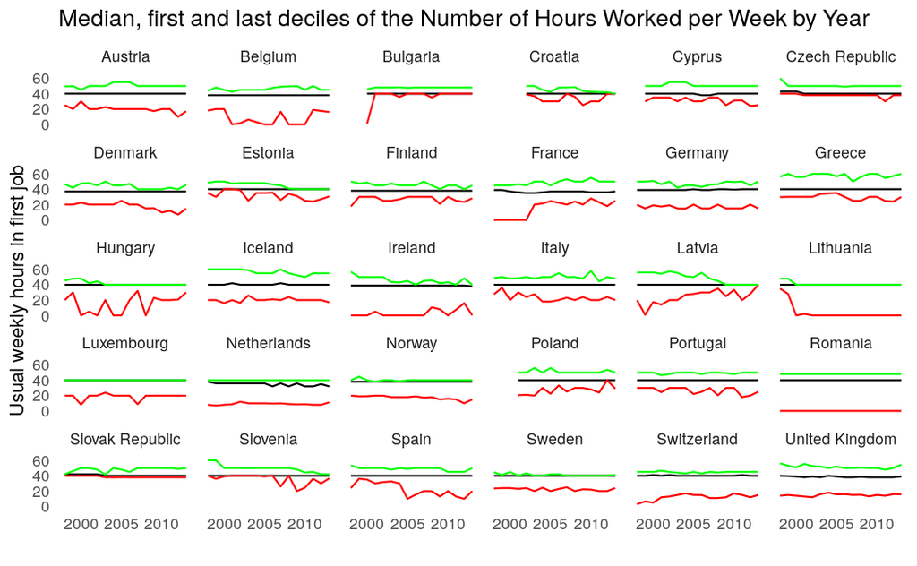

```r
# Convert the "year" and "country" variable to a factor for correct visualization in the histogram
eulfs_small$year <- as.factor(eulfs_small$year)
eulfs_small$country <- as.factor(eulfs_small$country)

# Remove values 99 (not applicable) from the hwactual variable
eulfs_small$hwusual <- na_if(eulfs_small$hwusual, 99)
# Filter data to exclude NA values in the hwactual variable
eulfs_filtered <- eulfs_small %>% filter(!is.na(hwusual))
eulfs_filtered <- merge(eulfs_filtered, countries_code, by="country")

median_by_country_year <- eulfs_filtered %>%
  group_by(country_name, year) %>%
  summarise(median_hwusual = median(hwusual, na.rm = TRUE))
median_by_country_year <- median_by_country_year %>%
  filter(country_name != "Malta")
median_by_country_year$year <- as.numeric(as.character(median_by_country_year$year))

# Same thing with the 1st decile
dec1_by_country_year <- eulfs_filtered %>%
  group_by(country_name, year) %>%
  summarise(dec1_hwusual = quantile(hwusual, probs = 0.10, na.rm = TRUE))
dec1_by_country_year <- dec1_by_country_year %>%
  filter(country_name != "Malta")
dec1_by_country_year$year <- as.numeric(as.character(dec1_by_country_year$year))

# Same thing with the 9th decile
dec9_by_country_year <- eulfs_filtered %>%
  group_by(country_name, year) %>%
  summarise(dec9_hwusual = quantile(hwusual, probs = 0.90, na.rm = TRUE))
dec9_by_country_year <- dec9_by_country_year %>%
  filter(country_name != "Malta")
dec9_by_country_year$year <- as.numeric(as.character(dec9_by_country_year$year))

# Into one single dataframe
frame_med_dec <- median_by_country_year %>% left_join(dec1_by_country_year, by = join_by(country_name, year)) %>% left_join(dec9_by_country_year, by = join_by(country_name, year))

frame_med_dec %>% ggplot(aes_string(x = frame_med_dec$year, group=1)) +
  geom_line(aes(y = frame_med_dec$median_hwusual)) +
  geom_line(aes(y = frame_med_dec$dec1_hwusual), color = "red") +
  geom_line(aes(y = frame_med_dec$dec9_hwusual), color = "green") +
  labs(
    title = "Median, first and last deciles of the Number of Hours Worked per Week by Year",
    x = "",
    y = "Usual weekly hours in first job"
  ) +
  theme_minimal()+
  ylim(0,65)+
  facet_wrap(~country_name)+
  scale_x_continuous(breaks = c(2000,2005,2010))+
  theme(panel.grid = element_blank())
```

Figure 7. **Median weekly working hours are stable over time and across countries contrary to top and bottom deciles**. A few order statistics: the bottom decile, the median and the top decile of the number of hours usually worked in main job. 30 countries from the 2014 release of the EU Labor Force Survey, own analyses.

For each country, the situation stays somewhat stable over time, with a few exceptions: strong variation concerning the bottom decile in Hungary in particular and in other countries to a smaller extent. However, the situation varies a lot across countries. In some parts of Europe (Hungary, Lithuania, Luxembourg, Norway, Sweden), the top decile is at the same level as the median. In other parts of Europe (Bulgaria, Czech Republic, Slovak Republic), on the contrary, the bottom decile is at the same level as the median. We may also notice that the bottom decile is much more variable than the top one, across countries and over time. We do not see any significant effect of the 2008 crisis. The Netherlands are an exception since its median is slightly decreasing, or at least more variable than any other median. Romania and Lithuania are particular cases: both have a very low bottom decile.

We seem to have a problem with Romania: top and bottom deciles are much more stable than in other countries.

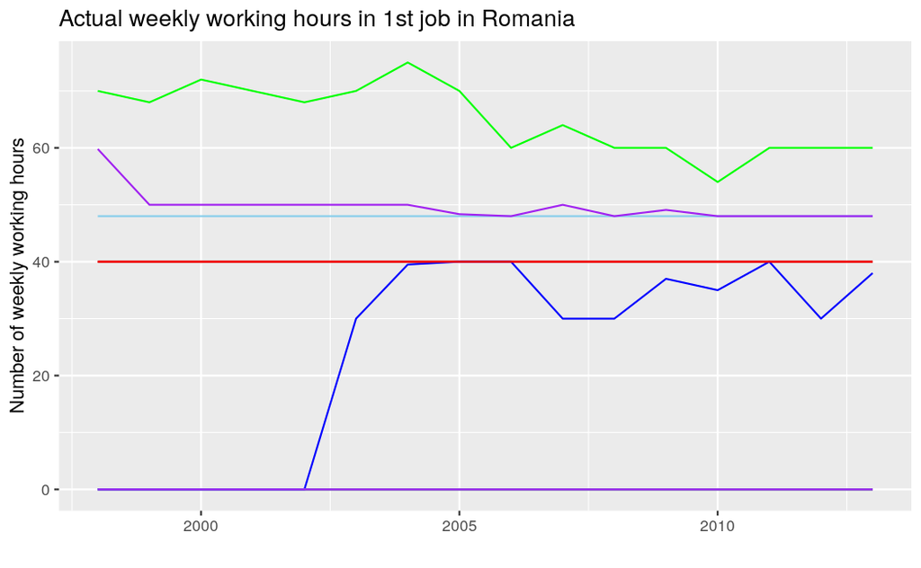

```r
# Starting by creating a smaller base to work with
eulfs_RO <- eulfs_small %>% filter(country == 27) %>% select(hwusual, refyear)
# Indicating what statistics we want to appear on the plot
frame <- eulfs_RO %>% group_by(refyear, .drop = NA) %>% summarise(Min = min(hwusual, na.rm = TRUE), Max = max(hwusual, na.rm = TRUE), Median = median(hwusual, na.rm = TRUE), quant1 = quantile(hwusual, probs = 0.25, na.rm = TRUE), quant2 = quantile(hwusual, probs = 0.75, na.rm = TRUE), dec1 = quantile(hwusual, probs = 0.10, na.rm = TRUE), dec9 = quantile(hwusual, probs = 0.90, na.rm = TRUE), dec05 = quantile(hwusual, probs = 0.05, na.rm = TRUE), dec95 = quantile(hwusual, probs = 0.95, na.rm = TRUE))
# Creating the graph
p <- ggplot(frame, aes(x = refyear, na.rm = TRUE)) + geom_line(aes(y=Min)) + geom_line(aes(y=Max), color = "green") + geom_line(aes(y=Median), color = "darkred") + geom_line(aes(y=quant1), color = "blue") + geom_line(aes(y=quant2), color = "red") + geom_line(aes(y=dec1), color = "skyblue") + geom_line(aes(y=dec9), color = "skyblue") + geom_line(aes(y=dec05), color = "purple") + geom_line(aes(y=dec95), color = "purple") + labs(title = "Actual weekly working hours in 1st job in Romania", x=" ", y="Number of weekly working hours")
# Plotting the graph
p
```

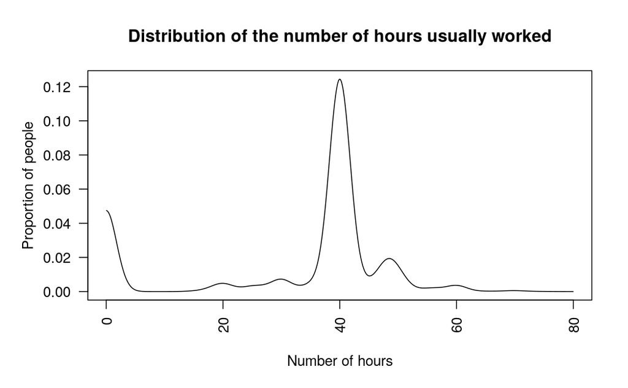

```r
# Get the density estimate
dens1 <- density(eulfs_RO$hwusual, na.rm = TRUE)
# Need to delete negative values for the number of working hours, as well as the values above 80 hours which are absent to the dataset
# Need for x and y with the same length
n <- length(dens1[[1]])
dens1[[1]] <- dens1[[1]][!(dens1[[1]] < 0)]
n_1 <- length(dens1[[1]])
loss_1 <- n - n_1 # number of first elements that were deleted
dens1[[1]] <- dens1[[1]][!(dens1[[1]] > 80)]
loss_2 <- n_1 - length(dens1[[1]]) # number of last elements that were deleted
dens1[[2]] <- tail(dens1[[2]],-loss_1)
dens1[[2]] <- head(dens1[[2]], -loss_2)

##### Plot -------
# Plot y-values scaled by number of observations against x values
par(mar = c(5.1, 5.1, 4.1, 2.1))
plot <- plot(dens1$x, dens1$y,type="l",xlab="Number of hours",ylab="", main = "Distribution of the number of hours usually worked", las = 2)
title(ylab = "Proportion of people", line = 3) # a readable y-label
```

One explanation is the high rate of emigration: one person finds work in another country and becomes the bread-winner of a whole family. For instance, a couple made up of a male immigrant and a housewife.

We may analyse data for an other specific country, for instance Austria.

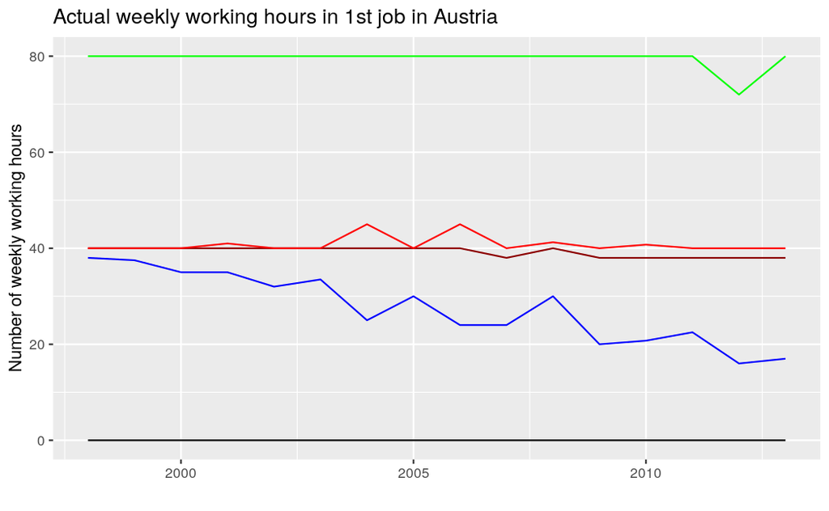

```r
# Starting by creating a smaller base to work with
eulfs_AT <- eulfs_small %>% filter(country == 1) %>% select(hwactual, refyear)
# Indicating what statistics we want to appear on the plot
frame <- eulfs_AT %>% group_by(refyear, .drop = NA) %>% summarise(Min = min(hwactual, na.rm = TRUE), Max = max(hwactual, na.rm = TRUE), Median = median(hwactual, na.rm = TRUE), quant1 = quantile(hwactual, probs = 0.25, na.rm = TRUE), quant2 = quantile(hwactual, probs = 0.75, na.rm = TRUE))
# Creating the graph
p <- ggplot(frame, aes(x = refyear, na.rm = TRUE)) + geom_line(aes(y=Min)) + geom_line(aes(y=Max), color = "green") + geom_line(aes(y=Median), color = "darkred") + geom_line(aes(y=quant1), color = "blue") + geom_line(aes(y=quant2), color = "red") + labs(title = "Actual weekly working hours in 1st job in Austria", x=" ", y="Number of weekly working hours")
# Plotting the graph
p
```

Figure 10. **Those who work the least tend to have less and less working hours in recent years in Austria**. A few order statistics concerning Austria: the minimum, the three quartiles and the maximum of the number of hours actually worked in main job. From the 2014 release of the EU Labor Force Survey, own analyses.

We notice that all quartiles remain somewhat stable, except the first quartile. Indeed, the quarter of the population who work the least has less and less working hours. The number of hours dropped below 20 hours after 2010.